# (Prosper Loan Dataset Exploration)

## By (Moshira Ezzat Mostafa)

## Investigation Overview

> This is a data analysis for investigating the borrower rate and its interrelationships with other variables.

## Dataset Overview

> We used a financial dataset from Prosper lending marketplace, it contains 113,937 loans with 81 variables, and stores information about Loans, Borrowers, Lenders, Interest rates and many other variables through the time from 2005 to 2014.

```python
# import all packages and set plots to be embedded inline
import numpy as np
import pandas as pd
import matplotlib.pyplot as plt
import seaborn as sb

%matplotlib inline

# suppress warnings from final output
import warnings
warnings.simplefilter("ignore")
```

```python
# load in the dataset into a pandas dataframe
df= pd.read_csv('prosperLoanData.csv')
```

## 1- Tracking the change in the borrower rate over time

> Firstly, we tracked the change in the borrower rate provided by Prosper market over years.
> - The line plot showed that the borrower rate dramatically grew up in 2005 and 2006, but slightly dropped in 2007. Then, it gradually increased through the years until it reached its highest in 2011. After that, it gradually dropped again through 2012 till 2014

```python
df['LoanOriginationDate']= pd.to_datetime(df['LoanOriginationDate'])
df['LoanOriginationYear']= df['LoanOriginationDate'].dt.year
```

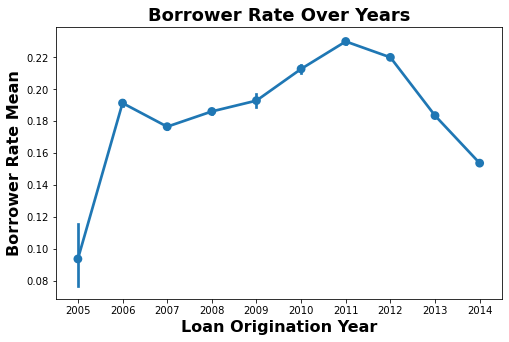

```python
# plot a line for the borrower rate over time
plt.figure(figsize=[8,5])
sb.pointplot(data= df, x='LoanOriginationYear', y='BorrowerRate')
plt.xlabel('Loan Origination Year', fontsize= 16, weight= 'bold')
plt.ylabel('Borrower Rate Mean', fontsize= 16, weight= 'bold')
plt.title('Borrower Rate Over Years', fontsize= 18, weight= 'bold');
```

## 2- Overview of the borrower rate interactions with other variables

> Then, we created a heat map to explore the interactions between the borrower rate and other variables which are expected to influence the rate. The data revealed
> - Strong positive association with loan estimated return (r= 0.82), and estimated loss (r= 0.95)
> - Strong negative association with prosper score (r= -0.65)
> - Weak Negative association with the loan amount (r= -0.33), and the monthly loan payment (r= -0.24)
> - No association with stated monthly income (r=-0.089), and DIR (r= 0.063)

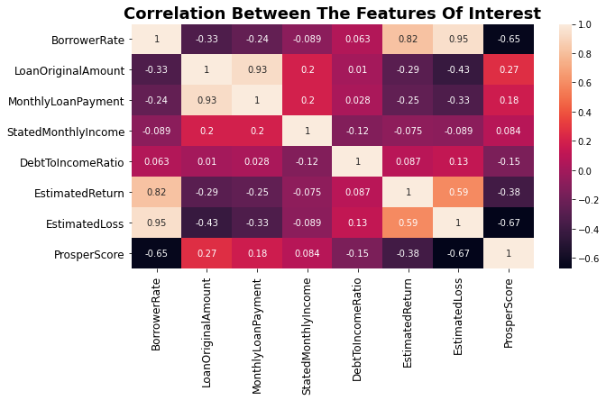

```python
# plot a heat map explore the correlations between the features of interest
col= ['BorrowerRate','LoanOriginalAmount','MonthlyLoanPayment','StatedMonthlyIncome', 'DebtToIncomeRatio', 'EstimatedReturn', 'EstimatedLoss', 'ProsperScore']
plt.figure(figsize = [10, 5])
sb.heatmap(df[col].corr(), annot=True)
plt.xticks(fontsize=12)
plt.yticks(fontsize=12)
plt.title('Correlation Between The Features Of Interest', fontsize= 18, weight= 'bold');
```

## 3- Effect of borrower income on the borrower rate

> Next, we used the box plot to explore the effect of the borrower income range on the rate.
> - The box plot revealed that as the income increase, the interest rate decrease. Thus, not-employed borrowers recieve the highest interest rate.

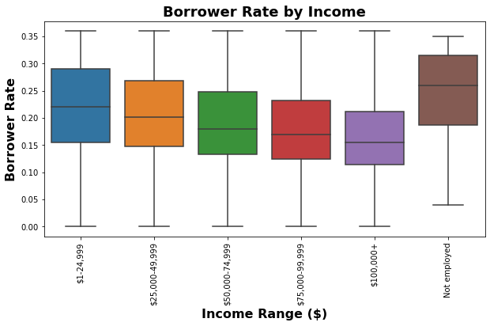

```python
# plot boxplot between the borrower rate and the income range
plt.figure(figsize=[10,5])
income_order= ['$1-24,999', '$25,000-49,999', '$50,000-74,999', '$75,000-99,999', '$100,000+', 'Not employed']
sb.boxplot(data= df, x= 'IncomeRange', y='BorrowerRate', order= income_order)
plt.xlabel('Income Range ($)', fontsize= 16, weight= 'bold')
plt.ylabel('Borrower Rate', fontsize= 16, weight= 'bold')
plt.xticks(rotation= 90)
plt.title('Borrower Rate by Income', fontsize= 18, weight= 'bold');
```

## 4- The impact of home owning on the Borrower rate

> Moreover, we explored the borrower rate recieved by home owners and non-home owners borrowers.
> - As expected, the box plot showed that home owners recieve lower interest rate than non-home owners.

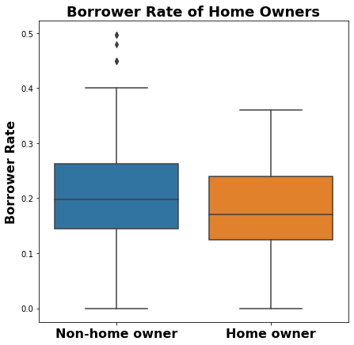

```python
#plot boxplot between the borrower rate and borrower home owner
plt.figure(figsize= [7,7])
sb.boxplot(data=df, x='IsBorrowerHomeowner', y='BorrowerRate')
plt.xlabel(None)
plt.ylabel('Borrower Rate', fontsize=16, weight= 'bold')
xticks= np.arange(2)
xticks_labels= ('Non-home owner', 'Home owner')
plt.xticks(xticks, xticks_labels, fontsize=16, weight= 'bold')
plt.title('Borrower Rate of Home Owners', fontsize=18, weight= 'bold');
```

## 5- Effect of loan term, and prosper score on the borrower rate

```python
# add 'months' word at the end of the term column values
df['Term'] = df['Term'].astype(str) + ' months'
```

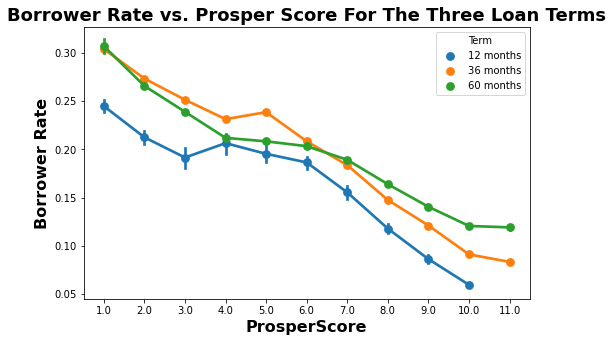

```python
#plot a line plot  describing the relationship between borrower rate and prosper score by terms
plt.figure(figsize=(8, 5))
term_order=['12 months', '36 months', '60 months']
sb.pointplot(data=df, y='BorrowerRate', x='ProsperScore', hue= 'Term', hue_order= term_order)
plt.ylabel('Borrower Rate', fontsize= 16, weight= 'bold')
plt.xlabel('ProsperScore', fontsize= 16, weight= 'bold')
plt.title('Borrower Rate vs. Prosper Score For The Three Loan Terms', fontsize= 18, weight='bold');
```

## 6- Risk assessment of the high borrower rate loans

> Surprisingly, we noticed in the previous overview heat map a strong positive correlation between the borrower rate and the estimated loan loss, where it was expected to show negative association, so we decided to draw a scatter plot exploring this relation according to the risk score.
> - Interestingly, the scatter plot conveyed that loans with high borrower rate and high estimated loss have high risk (i.e: low prosper score)

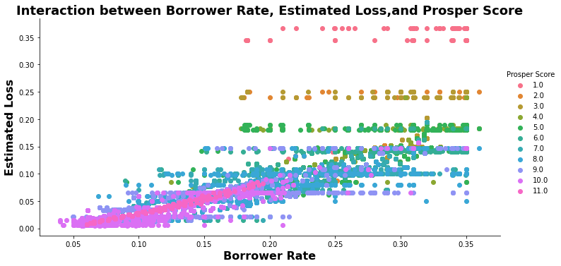

```python
# plot a scatterplot  describing the relationship between borrower rate and estimated return and the prosper score
g = sb.FacetGrid(data = df, hue = 'ProsperScore', height= 5, aspect= 2)
g.map(plt.scatter, 'BorrowerRate', 'EstimatedLoss')
g.add_legend(title= 'Prosper Score')
plt.xlabel('Borrower Rate', fontsize= 16, weight= 'bold')
plt.ylabel('Estimated Loss', fontsize= 16, weight= 'bold')
plt.title('Interaction between Borrower Rate, Estimated Loss,and Prosper Score', fontsize= 18, weight= 'bold');
```

## 7- Effect of the borrower rate on the estimated return and loss

> Lastly, we create a scatter plot to reflect the interactions between the borrower rate and the estimated loan return and loss.
> - The plot clarified that loans with high interest rate and high estimated return have low estimated loss.

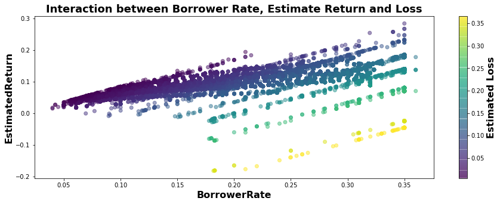

```python
# plot a scatter plot showing the relationship between the borrower rate, estimated return and the estimated loss
plt.figure(figsize=[15,5])
plt.scatter(data = df, x = 'BorrowerRate', y = 'EstimatedReturn', c = 'EstimatedLoss', alpha= 0.5)
cb= plt.colorbar()
cb.set_label(label= 'Estimated Loss', fontsize= 16, weight='bold')
plt.xlabel('BorrowerRate', fontsize= 16, weight= 'bold')
plt.ylabel('EstimatedReturn', fontsize= 16, weight= 'bold')
plt.title('Interaction between Borrower Rate, Estimate Return and Loss', fontsize= 18, weight='bold');
```